# R Notebook

Code for stepwise regression in R

Prep the workspace

```r
rm(list = ls())
library(MASS)
library(caret)
library(dplyr)
```

Load the draft data

```r
KA<-read.csv("/Users/ebar/Dropbox/1Courses/ResearchGroup/2019-2020/Kate Andy/Covariates.draft.csv")

LS<-read.csv("/Users/ebar/Dropbox/1Courses/ResearchGroup/2019-2020/Leslie/SYEvariables.csv")
```

Deal with NA’s.

Stepwise regression won’t work well if you have different amounts of data for the different regression runs. Thus, we need a data set with the same data for each regression model. In Kate’s data, there are some cameras for which there were no species detected. We will delete them from the data set.

```r
dump<-which(is.na(KA$SpecRichness))
KA<-KA[-dump,]
```

Isolate response and predictor variables

```r
Kresponse<-KA[, 7:10]
Kpreds<- KA[, c(4, 6, 11:47)]
Kpreds<- dplyr::select(Kpreds, -starts_with("P_Barren"))
```

Now if there are any predictors remaining for which there are NA’s, we should remove them from the predictor list. Use dplyr to find them.

```r
haveNAs<-Kpreds %>% select_if(function(x) any(is.na(x))) %>% names()
#returns column names that contain NAs
```

Now remove those columns from Kpreds

```r
Kpreds<-dplyr::select(Kpreds, - all_of(haveNAs))
```

Now let’s run a stepwise regression

Set seed for reproducibility

```r
set.seed(123)
```

Using MASS

```r
full.model<-lm(Kresponse$SpecRichness ~ ., data = Kpreds)
step.model<-stepAIC(full.model, direction = "both", trace = FALSE)
summary(step.model)
```

```
Call:
lm(formula = Kresponse$SpecRichness ~ Season + P_Wetland50 +
    Cam_Orient + P_Wetland100, data = Kpreds)

Residuals:
    Min      1Q  Median      3Q     Max
-5.4760 -2.7391 -0.1179  3.0204  7.3455

Coefficients:
              Estimate Std. Error t value Pr(>|t|)
(Intercept)   8.318071   1.171392   7.101 9.99e-10 ***
SeasonSpring -4.004786   1.067770  -3.751  0.00037 ***
SeasonSummer -2.426493   1.248915  -1.943  0.05623 .
SeasonWinter -3.561594   1.119819  -3.181  0.00223 **
P_Wetland50   0.103260   0.050124   2.060  0.04328 *
Cam_Orient    0.006542   0.003808   1.718  0.09040 .
P_Wetland100 -0.083720   0.061644  -1.358  0.17898
---
Signif. codes:  0 ‘***’ 0.001 ‘**’ 0.01 ‘*’ 0.05 ‘.’ 0.1 ‘ ’ 1

Residual standard error: 3.457 on 67 degrees of freedom
Multiple R-squared:  0.2563,    Adjusted R-squared:  0.1897
F-statistic: 3.848 on 6 and 67 DF,  p-value: 0.002342
```

Another approach following [this website](https://www.statology.org/stepwise-regression-r/)

Start by defining the intercept-only model

```r
m.intercept_only<-lm(Kresponse$SpecRichness ~ 1, data = Kpreds)
```

Define the total model

```r
m.total<-lm(Kresponse$SpecRichness ~ ., data = Kpreds)
```

Perform stepwise regression

```r
m.stepwise<-step(m.intercept_only, direction = "both", scope = formula(m.total))
```

```
Start:  AIC=200.12
Kresponse$SpecRichness ~ 1

                  Df Sum of Sq     RSS    AIC
+ Season           3   183.984  892.35 192.25
+ Cam_Orient       1    36.015 1040.32 199.60
+ P_Evergreen50    1    33.148 1043.19 199.80
+ P_Wetland50      1    31.327 1045.01 199.93
<none>                         1076.34 200.12
+ Cam_Orient100    1    20.225 1056.11 200.71
+ Cam_Model        1    18.703 1057.63 200.82
+ RoadDensity50    1    18.160 1058.18 200.86
+ P_Deciduous50    1    17.146 1059.19 200.93
+ PlotSize50       1    16.085 1060.25 201.00
+ Slope50          1    15.097 1061.24 201.07
+ P_Agriculture50  1    11.303 1065.03 201.34
+ Elevation50      1     8.489 1067.85 201.53
+ P_Herb50         1     7.713 1068.62 201.59
+ RoadDensity100   1     7.097 1069.24 201.63
+ P_Forest50       1     6.126 1070.21 201.69
+ P_Shrub100       1     4.949 1071.39 201.78
+ ForestType       1     3.905 1072.43 201.85
+ P_Development50  1     3.481 1072.86 201.88
+ PlotSize100      1     2.908 1073.43 201.92
+ P_Forest100      1     1.375 1074.96 202.02
+ Slope100         1     1.205 1075.13 202.03
+ P_Deciduos100    1     0.966 1075.37 202.05
+ P_Wetland100     1     0.773 1075.56 202.06
+ P_Mixed100       1     0.768 1075.57 202.06
+ P_Mixed50        1     0.733 1075.61 202.07
+ P_Evergreen100   1     0.175 1076.16 202.10
+ Elevation100     1     0.162 1076.18 202.11
+ PPT_50           1     0.153 1076.19 202.11
+ P_Shrub50        1     0.034 1076.30 202.11
+ PPT_100          1     0.010 1076.33 202.12

Step:  AIC=192.25
Kresponse$SpecRichness ~ Season

                  Df Sum of Sq     RSS    AIC
```

[output cut: 125 more lines]

```
+ P_Evergreen100   1     2.129  795.91 191.78
+ P_Deciduos100    1     1.650  796.39 191.83
+ RoadDensity50    1     1.435  796.61 191.85
+ Cam_Model        1     1.267  796.77 191.86
+ P_Mixed100       1     0.577  797.47 191.93
+ PlotSize50       1     0.490  797.55 191.93
+ P_Herb50         1     0.397  797.65 191.94
+ Cam_Orient100    1     0.372  797.67 191.94
+ PPT_100          1     0.299  797.74 191.95
+ P_Shrub100       1     0.227  797.82 191.96
+ P_Forest100      1     0.139  797.90 191.97
+ P_Forest50       1     0.077  797.97 191.97
+ Elevation100     1     0.014  798.03 191.98
+ P_Development50  1     0.002  798.04 191.98
- Season           3   202.299 1000.34 200.70
```

Now run the final model

```r
summary(m.final)
```

```
Call:
lm(formula = Kresponse$SpecRichness ~ Season + P_Wetland50 +
    Cam_Orient + Elevation50, data = Kpreds)

Residuals:
    Min      1Q  Median      3Q     Max
-5.6885 -3.0497 -0.1638  2.6148  7.3650

Coefficients:
              Estimate Std. Error t value Pr(>|t|)
(Intercept)   9.921067   1.889172   5.252 1.68e-06 ***
SeasonSpring -4.089225   1.072555  -3.813 0.000302 ***
SeasonSummer -2.900895   1.256222  -2.309 0.024022 *
SeasonWinter -3.474572   1.102590  -3.151 0.002431 **
P_Wetland50   0.084556   0.049464   1.709 0.091998 .
Cam_Orient    0.006068   0.003792   1.600 0.114292
Elevation50  -0.009644   0.006724  -1.434 0.156114
---
Signif. codes:  0 ‘***’ 0.001 ‘**’ 0.01 ‘*’ 0.05 ‘.’ 0.1 ‘ ’ 1

Residual standard error: 3.451 on 67 degrees of freedom
Multiple R-squared:  0.2586,    Adjusted R-squared:  0.1922
F-statistic: 3.894 on 6 and 67 DF,  p-value: 0.002145
```

All subsets regression. See [this webpage](https://educationalresearchtechniques.com/2017/02/24/subset-regression-in-r/)

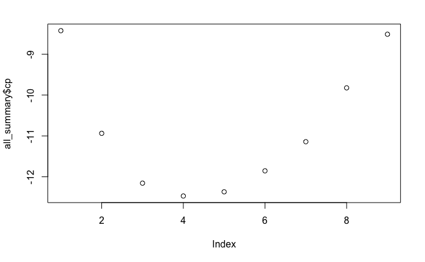

Plot some results for model comparison

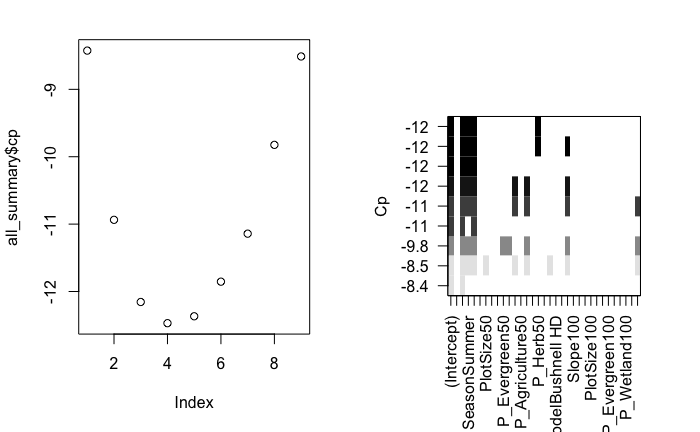

```r
#base plotting
par(mfrow = c(1,2))
plot(all_summary$cp)
plot(m.all_subsets,scale = "Cp")
```

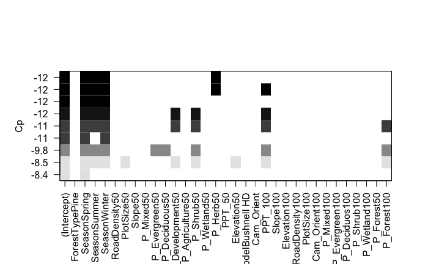

And now use bayesian information criterion BIC

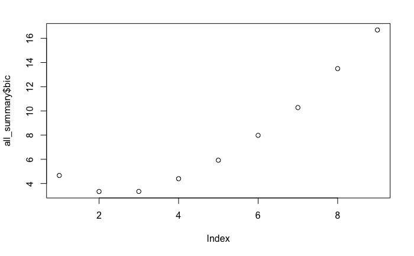

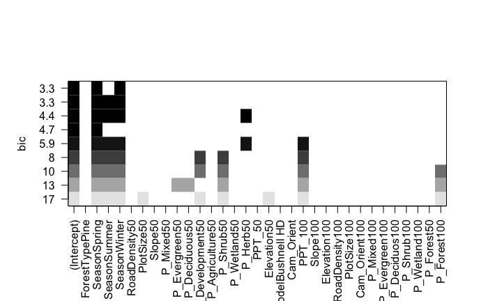

```r
plot(m.all_subsets, scale = "bic")
```